# Black Seed

Novin Ghaffari

2023-05-05

# 1 Overview

Black seed, *Nigella sativa*, is a annual flowering herb native to Western Asia and Eastern Europe. It has a long history of medicinal use dating back to the ancient world. Modern scholarship and clinical evidence has found some evidence to support medicinal effects and elucidate mechanisms of action.

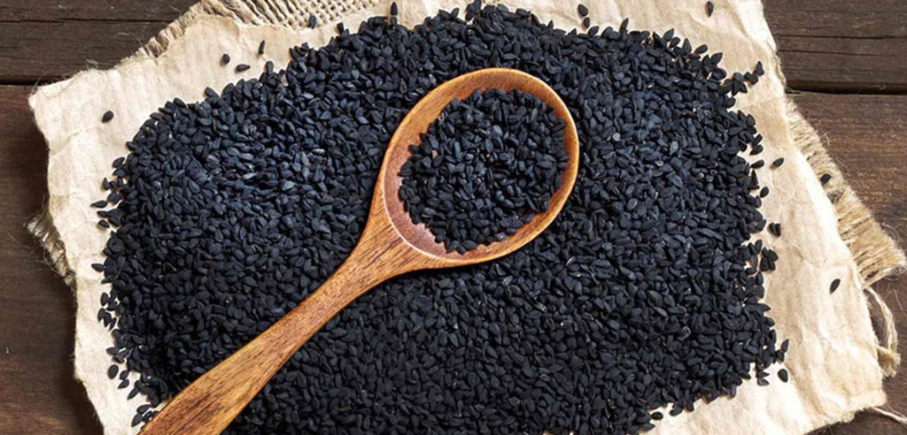

Black seeds

# 2 Etymology, Taxonomy, History

One study recovered black seed seeds from a pilgrim flask found in north-central Turkey dating to the Old Hittite period (1650BC). A GC-MS analysis of the seeds found the content of the essential oil similar to modern samples (1).

Black seed and its oil has been recovered from the tomb of Tutankhamun dating to 1325BC. This, along with references to its medicinal usage, indicates the importance of black seed in ancient Egyptian society (2).

In Hebrew the word for black seed is (קֶצַח) [qeṣaḥ], possibly deriving from a Ugaritic word. Black seed is mentioned in the bible in Isaiah 28:25. Black seed occurs under several names in Arabic, including (حبة البركة) [ḥabbat al-baraka] and (الحبة السوداء) [al-ḥabbat al-sawdā’]. In the hadith corpus, Muhammad is reputed to have recommended black seed as a catch-all cure for every ailment, “except death.”

In Hindi black seed is referred to as ‘kalonji’ (कलौंजी). It has a number of uses in Ayurveda, the traditional Indian system of medicine. In India, black seed is also popular as a culinary condiment for its intense, unique flavor. In ancient Greek the seeds were referred to as ‘melanthion’ (μελᾰ́νθῐον) and were recommended as medicines by both Hippocrates and Discorides for a host of ailments. Later the Roman-Greek physician Galen wrote about the benefits of black seed. In Persian black seed is referred to as (سیاه دانه) [siyāhdāne]. It was recommended by the Iranian polymaths Ibn Sina (Avicenna) in his highly influential ‘Canon of Medicine’ and Biruni in his compendium of medicines (3).

The largest producers of black seed are India, Iran, Pakistan, Turkey, Syria, and Egypt. The largest importers are Brazil, Canada, Colombia, European Union, Ecuador, Japan, Malaysia, Mexico, South Africa, and the USA (3).

# 3 Taste, Appearance, Flavor, and Aroma

Seeds are angular, trigonus, and somewhat elongated; they are black on the outside and white inside. The aroma and flavor are complex, being described as a cross between onion, thyme, black pepper, and sesame seed flavors (4).

# 4 Active Constituents

One study reported the composition of black seeds as:

- **protein**: ($26.7\%$, (5))
- **fat**: ($28.5\%$, (5))
- **carbohydrates**: ($24.9\%$, (5))
- **fiber**: ($8.4\%$, (5))
- **total ash**: ($4.8\%$, (5))

The *Nigella sativa* seeds contain a fatty oil that is abundant in unsaturated fatty acids:

- **linoleic acid**: ($50\%-60\%$, (5))
- **oleic acid**: ($20\%$, (5))
- **dihomolinoleic acid**: ($10\%$, (5))
- **eicodadienoic acid**: ($3\%$, (5))

Saturated fatty acids, primarily palmitic and stearic acid, constitute about 30% of the fatty oil fraction (5).

The following trace metals and minerals have been detected in *Nigella sativa*:

- **Calcium (Ca)** (6)
- **Copper (Cu)** (5),
- **Iron (Fe)** (5), (6)
- **Phosphorus (P)** (5), (6)
- **Potassium (K)** (6)
- **Zinc (Zn)** (5), (6)

The following elements are constituents of the fatty and essential oils (5), (7):

```r
df = data.frame(
  Group = c(
    rep("fixed Oil",6),
    rep("terpenes",11),
    rep("alkaloids",15),
    rep("coumarins",3),
    rep("saponins",3),
    rep("flavonoids",4),
    rep("phenolics",4)
  ),
  Subgroup = c(
    rep("unsaturated fatty acids",4),
    rep("saturated fatty acids",2),
    rep("aliphatic",11),
    rep("isoquinoline alkaloids",4),
    rep("pyrazole alkaloids",2),
    rep("dolabellane diterpenes",9),
    "hydroxy coumarin",
    "methoxy coumarin",
    "oxy coumarin",
    "steroidal",
    rep("triterpenes",2),
    "flavonoidal pigments",
    rep("flavonoidal glycosides",3),
    rep("acid phenolics",4)
  ),
  Actives = c(
    "dihomolinoleic acid",
    "eicodadienoic acid",
    "linolenic acid",
    "oleic acid",
    "palmitic acid",
    "stearic acid",
    "thymoquinone",
    "dithymoquinone (nigellone)",
    "thymohydroquinone",
    "p-cymene",
    "α-pinene",
    "carvacrol",
    "carvone",
    "limonene",
    "4-terpineol",
    "citronellol",
    "anethol",
    "nigellimine",
    "nigellimine N-Oxide",
    "nigellicimine",
    "nigellicimine N-Oxide",
    "nigellicine",
    "nigellidine",
    "nigellamine A1",
    "nigellamine A2",
    "nigellamine A3",
    "nigellamine A4",
    "nigellamine A5",
    "nigellamine B1",
    "nigellamine B2",
    "nigellamine C",
    "nigeglamine",
    "6-methoxy-coumarin",
    "7-hydroxy-coumarin",
    "7-oxy-coumarin",
    "α-hederin",
    "steryl glucosides",
    "acetyl-steryl-glucoside",
    "quercetin",
    "kaempferol 3-glucosyl galactosyl glucoside",
    "quercetin 3-galactosyl glucoside",
    "trigillin quercetin-3-glucoside",
    "vanillic acid",
    "hydroxybenzoic acid",
    "syringic acid",
    "p-cumaric acids"
  )
)
```

One survey of several studies characterizing the essential oil of *Nigella sativa* found that thymoquinone ranged from 0.6%-52.6% and *p*-cymene ranged from 14.1%-60.5% as a percentage of the total composition (8).

```r
thymoquinone = c(4.47, .79,11.27,.6,42.4,3,52.6)
pcymene = c(56.67,49.48,36.2,14.8,14.1,60.5,25.8)

writeLines("Correlation of Thymoquinone and p-cymene compositions")
corr = as.numeric(format(cor(thymoquinone,pcymene), digits = 3))
corr
```

```
## Correlation of Thymoquinone and p-cymene compositions
## [1] -0.553
```

Another study examined the variation in terpenoid content over the life cycle of *Nigella sativa*. Almost none of the characteristic monoterpenes of the seeds are present in the flowers. Flower extracts were found to mainly contain 2E-hexanal, 2E-hexenol, and t-caryophyllene. Terpene accumulation begins after pollination at around 30 days. $\gamma$-terpinene is the first terpene to begin increasing in concentration, almost immediately after pollination and seed formation. Thymoquinone, thymohydroquinone, and carvacrol begin increasing at day 50. At day 55 $\gamma$-terpinene levels begin dropping off. Thymoquinone appears to peak at day 65, other constituents continue to increase through the end of the plant-seed life cycle (75 days). These trajectories of terpene concentrations are depicted below in Figure 2 from the paper (9):

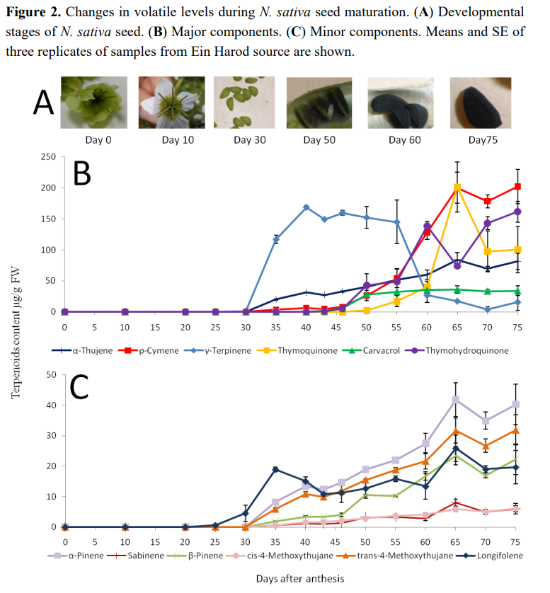

Reprinted from “Distribution of Primary and Specialized Metabolites in Nigella sativa Seeds, a Spice with Vast Traditional and Historical Uses”, by Botnick, I. et al., 2012, *Molecules*, p. 10164, Figure 2

# 5 Active Effects

## 5.1 Anti-Asthmatic & Bronchodilator

### 5.1.1 [Salem et al. 2017]

One study examined the bronchodilator and anti-asthmatic effects of *Nigella sativa* seeds in 76 18-65 year olds with asthma. Participants had to meet inclusion criteria. Of the total, 24 were assigned to control and given placebo (500mg capsule twice daily), 26 to crushed black seed 1g/day (500 mg capsule twice daily), 26 to crushed black seed 2g/day (2 500mg capsules twice daily). The day patients were assigned to their groups and given their treatments during their first visit (visit 0, week 0) and subsequently checked on twice (visit 1, week 6 and visit 2, week 12). Clinical assessment, spirometry, measurement of fractional exhaled nitric oxide (FeNO) and serum ‘total immunoglobulin E’ (IgE) were measured on all visits. Cytokines were measured on visits 0 and 2.

Asthma symptoms were measured via the Asthma control test (ACT). Other measures used included forced expiratory volume at 1 second (FEV1), forced vital capacity (FVC), forced expiratory volume (FEV25-75%), peak expiratory flow (PEF), fractional exhaled nitric oxide (FeNO), and immunoglobulin E (IgE) levels. For cytokine analysis, 8 ml of blood was taken, and levels of the following cytokines (IL - interleukin and IFN - interferon) were checked: IL-4, IL-10, IL-17, IFN-$\gamma$, and eotaxin.

The administration of *Nigella sativa* had a pronounced effect ($p<.01$) in improving ACT scores at weeks 6 and 12 as compared to controls. Additionally, treated groups had a much lower rate of severe exacerbation than the control group. The administration of *Nigella sativa* also improved several measures of respiration. In particular the 2g/day dose was found to improve FEV1 and FEV25-75%, while both *Nigella sativa* groups showed gains in PEF over controls ($p$ values $<.05$). From the cytokines measured, only IFN-$\gamma$ was significantly different from baseline in the treatment groups, showing a statisticall significant ($p=.03$) increase. Low dose *Nigella sativa* was associated with statistically significant reductions in FeNO by week 12, whereas high dose was associated with statistically significant reductions in IgE by week 12.

For information see the study (10).

### 5.1.2 [He & Xu 2020]

A couple of Chinese researchers conducted a meta-analysis on trials of *Nigella sativa* as an asthma treatment. The study specifically sought randomized controlled trials comparing *Nigella sativa* to placebo. All studies used common outcome measures of the score on the asthma control test (ACT), forced expiratory volume at 1 second (FEV1), peak expiratory flow (PEF). In addition, all studies considered looked at two common cytokines (IL-4 and IFN-$\gamma$).

The researchers searched PubMed, EMbase, Web of science, EBSCO, and Cochrane library databases. In the end 4 studies were included and a random effects model was used for the meta-analysis. The following 4 studies were included:

1. Boskabady et al 2007 ($n=29$)
2. Barlianto et al 2017 ($n=28$)
3. Koshak et al 2017 ($n=80$)
4. Salem et al 2017 ($n=50$, didn’t include 2g/day group)

While all these studies met the inclusion criteria and were placebo-controlled randomized trials, there were notable differences (e.g., different age ranges and different format like crushed seeds or extracts).

Overall the authors found the following effects: * **ACT**: significant improvements in ACT score ($p=.01$) * **FEV1**: significant improvements in FEV1 ($p=.04$) * **PEF**: differences were trending toward significance ($p=.17$) * **IFN-$\gamma$**: differences were trending toward significance ($p=.16$) * **IL-4**: effects on IL-4 did not show any significance ($p=.5$)

For more see the analysis (11).

## 5.2 Anticancer

For *Nigella sativa* in general and its primary active thymoquinone in particular anticancer effects have been documented and studied in the peer-reviewed literature.

### 5.2.1 [Salomi et al. 1991]

An early study examined the anti-carcinogenic capacity of *Nigella sativa* alongside saffron, both reputed for their anticancer properties. Inbred Swiss albino mice were used for the study with 10 mice in each treatment group in each experiment, 3 experiments total (i.e. 30 total per treatment group over all experiments). A methanolic extract of *Nigella sativa* and a ethanolic-aqueous extract of *Crocus sativus* were created and used. Two separate experiments were conducted. Black seed and saffron were tested topically in one and internally in the other. In the topical experiment dimethylbenz[a]anthracene (DMBA) was used to induce skin carcinogenesis and papilloma formation. In the internal experiment 20-methylcholanthrene (MCA) was administered subcutaneously to induce soft tissue sarcoma. The application of DMBA was preceded by the administration of 100 mg/kg of black seed or saffron extract in treatment groups. MCA was administered by subcutaneous injections, and 30 days after chemical carcinogenesis treatment groups received 100 mg/kg of either black seed intraperitoneally or saffron by oral gavage. Controls received saline in the internal experiment and DMSO in the topical experiment.

For the skin carcinogenesis experiment, papilloma measurements were taken in weeks 6, 9, and 12 weeks. The following percent of animals had papillomas:

- **week 6**:
  - **control**: $56.6\%$
  - **black seed**: $33.3\%$
  - **saffron**: $26.6\%$
- **week 9**:
  - **control**: $76.6\%$
  - **black seed**: $33.3\%$
  - **saffron**: $26.6\%$
- **week 12**:
  - **control**: $90\%$
  - **black seed**: $76.6\%$
  - **saffron**: $50\%$

The following are the mean number of papillomas per animal with standard deviations * **week 6**: + **control**: $0.80 ± 0.5$ + **black seed**: $0.26 ± 0.13$ + **saffron**: $0.53 ± 0.35$ * **week 9**: + **control**: $2.0 ± 0.6$ + **black seed**: $0.53 ± 0.26$ + **saffron**: $0.57 ± 0.27$ * **week 12**: + **control**: $2.4 ± 0.5$ + **black seed**: $1.3 ± 0.6$ ($p<.02$) + **saffron**: $1.0 ± 0.3$($p<.01$)

- **week 8**:
  - **control**: $56.6\%$
  - **black seed**: $0\%$
  - **saffron**: $0\%$
- **week 12**:
  - **control**: $76.6\%$
  - **black seed**: $33.3\%$
  - **saffron**: $10\%$
- **week 20**:
  - **black seed**: $56.6\%$
  - **saffron**: $43\%$

Mean tumor diameters and standard deviations were: * **week 8**: + **control**: $0.83 ± 0.41$ + **black seed**: $-$ + **saffron**: $-$ * **week 12**: + **control**: $3.15 ± 0.52$ + **black seed**: $1.47 ± 0.48$ + **saffron**: $0.93 ± 0.26$

For details on this study see (12).

### 5.2.2 [Salomi et al. 1992]

A study directly tested the anticancer properties of *Nigella sativa* on several cancer cell lines, both cultured cells and cells transplanted into mice. Interestingly, the study found *Nigella sativa* had some inhibitory effect on lymphocyte-derived cell lines but was more potent against other cell lines.

For the cytotoxicity studies in mice, Swiss albino mice were intraperitoneally transplanted with Dalton’s lymphoma ascites cells (DLA), Ehrlich ascites carcinoma cells (EAC), or Sarcoma-180 cells (S-180). Mice were treated with varying levels of the black seed extract (.5-50 $\mu$g/ml). The following concentrations were 50% cytotoxic to each cell line (i.e. $50\%$ dead cells observed in assays):

- **DLA**: 3 $\mu$g/ml
- **EAC**: 1.5 $\mu$g/ml
- **S-180**: 1.5 $\mu$g/ml

By contrast doses of .28 mg/ml were needed for $50\%$ cytotoxicity to lymphocytes. In addition, the metabolism of nucleosides by the DLA lines were monitored. A drastic decrease in thymidine uptake was noted, indicating a possible mechanism of action. $50\%$ inhibition in uptake was achieved with doses of .1 $\mu$g/ml and $75\%$ inhibition with .2 $\mu$g/ml. The following effects were seen on average life span between controls, 50 mg/kg, and 100 mg/kg treatment groups:

- **EAC**:
  - **control**: $19.0 f 1.71$
  - **50mg/kg**: $31.18 f 3.78$ ($p<.001$)
  - **100mg/kg**: - (no tumors) ($p<.001$)
- **DLA**:
  - **control**: $24.38 f 4.96$
  - **50mg/kg**: $34.3 f 4.5$ ($p<.001$)
  - **100mg/kg**: $45.08 f 5.2$ ($p<.001$)

For the cultured cell study, KB (human oral carcinoma) cells and K-562 (human myelogenous leukemia). At .5 $\mu$g/ml $60\%$ inhibition of the KB cell line was achieved. By contrast, at doses of 10 $\mu$g/ml, the extract only retards K-562 growth in the first 24h and then growth of the cell line resumes.

For more details see the study (13).

### 5.2.3 [Worthen et al 1998]

One study evaluated *Nigella sativa* (gum and oil) as well as thymoquinone and dithymoquinone for anticancer activity via cytotoxicity against multidrug resistant (MDR) human tumor cell lines. Both thymoquinone and dithymoquinone were cytotoxic against all cell lines tested. Both parental cell lines and MDR descendents, which were 10 times more resistant to standard chemotherapy agents doxorubicin (DOX) and etoposide (ETP), were equally sensitive to thymoquinone and dithymoquinone. The addition of quinine potentiated the impacts of DOX and ETP on the MDR cell lines and reversed resistance. It had no effect on thymoquinone and dithymoquinone. The inclusion of DMSO, a free radical scavenger, reduced the cytotoxicity of DOX by 39%. It had no effect on thymoquinone and dithymoquinone. This study suggests that thymoquinone and dithymoquinone are cytotoxic in a manner that is independent of free radical generation. For more info see (14).

## 5.3 Anti-COVID-19

### 5.3.1 [Rahman 2020]

This literature review study raises the prospect of black seed oil being a powerful auxiliary treatment alongside zinc.

In humans, most zinc is stored intracellularly, with .1% of zinc found in the plasma. Excess free zinc ions can be toxic cells, so the body has a system of zinc transporter proteins that maintain intracellular homeostasis and balance intracellular and external zinc levels. Free zinc ions play an important role in activating certain immune functions and have inhibitory effects on viral replication.

During the pandemic there was much controversy over two proposed treatments: chloroquine and hydroxychloroquine. These compounds serve as ionophores, enhancing the cellular entry of ZN<sup>2+</sup> ions. The author identifies several terpene compounds in *Nigella sativa* oil that can mimic chloroquine’s ionophore capacity. The most promising constituent the author identifies is nigellimine.

The study notes that CD4+ and CD8+ lymphocyte levels are a potent predictor of COVID-19 outcomes. Black seed oil has been noted to boost levels of these lymphocytes.

For more see (15).

### 5.3.2 [Koshak et al. 2021]

An open-label study in Saudi Arabia found promising results for the use of *Nigella sativa* oil in the treatment of mild COVID-19. Adults 18 and older admitted to King Abdulaziz University Hospital in Jeddah with mild COVID-19 were recruited for the study between May 1 and September 31, 2020. Infections were confirmed via polymerase tests within a week of onset of symptoms. A total of 87 patients were in the control group and 86 in the treatment arm who received 500 mg of *Nigella sativa* oil (MARNYS® Cuminmar) twice daily.

The main outcome of interest was recovery with a 14 day window, with recovery defined as 3 consecutive days symptom-free. The number of days to recovery was secondary outcome of interest. The following results were found:

- **recovery rate**:
  - $35\%$ (control group)
  - $63\%$ (treatment group)
  - $p=.001$
- **recovery time**:
  - $12.4 ± 2.9$ (*days*, control group)
  - $10.7 ± 3.3$ (*days*, treatment group)
  - $p=.001$

For more see (16).

### 5.3.3 [Xu et al. 2021]

A Chinese research team combined computational and in-vitro experimental methods for a study on thymoquinone ability to prevent SARS-CoV-2 (as well as SARS-CoV and NL63) entry into cells via ACE-2.

Computational modeling studies showed that thymoquinone had a strong binding affinity for the ACE-2 receptor, effectively blocking the S1 subunit from binding to the receptor.

To prevent the spread of a real pathogen from the lab and to facilitate the study, pseudoviruses were created by loading SARS-CoV-2, SARS-CoV, and NL63 spike proteins into virus particles containing luciferase reporter genes. This way pseudovirus replication in cell cultures could be measured via fluorescence imaging. Thymoquinone had an IC50 of 5 $\mu$M for SARS-CoV-2, 7.598 $\mu$M for SARS-CoV, and 6.019 for NL63 pseudovirus.

For more see (17).

### 5.3.4 [Baig & Srinivasan 2022]

A molecular docking study funded by the Indian Ministry of Science and Technology and performed at the B.S. Abdur Rahman Institute of Science & Technology, Chennai examined the binding potential of various *Nigella sativa* oil constituents to various proteins of the COVID-19 virus. Chloroquine and its docking potentials were used as base cases.

The following COVID-19 proteins were tested for docking. The black cumin constituent with the highest docking potential is listed in parentheses:

- main protease (Alpha—hederin −8.8 (Kcal/Mol))
- papain-like protease (Nigellamine A2 -10.5 (Kcal/Mol))
- its helicase (Alpha—hederin −10.5 (Kcal/Mol))
- RNA-dependent RNApolymerase (Rutin −9.6 (Kcal/Mol))
- RNA-binding protein (Alpha—hederin −8 (Kcal/Mol))
- Endoribonuclease (Alpha—hederin −10.1 (Kcal/Mol))
- receptor-binding domain (Alpha—hederin −7.8 (Kcal/Mol))
- RNA-binding domain of nucleocapsid phosphoprotein (Alpha—hederin −9 (Kcal/Mol))

A handful of constituents for each protein showed high docking potential (low binding energy). The authors note an attractive aspect of this is black seed oil is well-tolerated whereas excessive zinc consumption can be harmful; hence by acting as an ionophore, black seed oil in conjunction with zinc could increase its efficacy without increasing its dose. For more see (18).

### 5.3.5 [Bencheqroun et al. 2022]

A double-blind, placebo-controlled study using a *Nigella sativa* oil formulation ThymoQuinone Formula (TF), which is an enteric-coated capsule standardized to 1.7% thymoquinone, examined its capacity to treat COVID-19. The study had a multi-center design, with trials taking place at the following institutions:

- RESPIRE Research, LLC, Palm Springs, CA, USA
- United Memorial Medical Center, Houston, TX, USA
- L&A Morales Clinic, Miami, FL, USA

Subjects were recruited based on several criteria, including being 18 years old or older and having mild to moderate symptoms (indicated by a FLU-PRO Plus assessment score of 3 or greater on at least 2 symptom scores). Sample sizes were small with only a total of 42 subjects completing all the study protocols with valid FLU-PRO scores. Primary outcomes safety/tolerability and time-to-sustained clinical response (SCR). SCR was defined as exhibiting all symptom scores less than or equal to 2 for 3 days. Several other outcomes of interest were also examined.

The following were observed:

- **adverse events** no significant different in adverse events indicating acceptable safety and tolerance
- **SCR** a difference of 2-2.5 days in SCR that was not statistically significant but was suggestive of being so under a larger sample size
- **viral load** viral load was not statistically significant at any time point measured, but there was a suggestive difference at day 7 and especially at day 14, indicating a larger sample size may be needed
- **T cells** there was a statistically significant increase in cytotoxic CD8<sup>+</sup> ($p=.042$) and CD4<sup>+</sup> ($p=.042$)
- **symptom burden** there was a statistically significant reduction in total symptom burden ($p<.001$) as well as of several individual symptoms

Additional exploratory in-vitro research found that TQF and thymoquinone had inhibitory effects against several strains of SARS-CoV-2 (‘omicron’,‘delta’,‘uk’,‘brazil’,‘614G’)

For more see (19).

### 5.3.6 [Sherwani et al. 2022]

One study examined several health-related impacts and anti-COVID of *Nigella sativa* oil through in-vitro and in-silico methods. For the study, black cumin seeds were crushed and a methanol extraction was prepared. The following aims were examined:

- **free radical scavenging**: two standard free radical scavenging assays were performed to determine antioxidant capacity of the extract
  - **DPPH**
  - **$H_2O_2$**
- **red blood cell membrane stability**: RBC membrane stability is adversely affected by COVID-19 and lead to lingering RBC membrane dysfunction; COVID patients’ RBCs have shown altered lipid metabolism and increased vulnerability to oxidative damage. Mitigating abilities of the extract were examined via the following
  - **heat-induced hemolysis inhibition**
  - **hyposaline-induced hemolysis inhibition**
- **advanced glycation end products**: diabetic patients are at increased risks with COVID-19; hyperglycemia results in increased glycation of biomolecules forming AGEs, and AGE formation is associated with increased inflammatory response and adverse outcomes
  - **browning intensity**
  - **protein aggregation index**
  - **AGEs-specific fluorescence tests**
- **molecular docking studies**: in-silico molecular docking studies were performed to assess the anti-viral capacity of several phytoconstituents present in the extract

The following results were observed:

- **$H_2O_2$**: the $H_2O_2$ assay found that at concentrations of 400-600 $\mu$g/ml the extract had comparable scavenging potential to 100-200 $\mu$g/ml of ascorbic acid ($p<.001$ vs control); at 600 $\mu$g/ml the extract had $70.28\%$ scavenging capacity
- **DPPH**: the DPPH assay found that at concentrations of 400-600 $\mu$g/ml the extract had comparable scavenging potential to 200 $\mu$g/ml of ascorbic acid ($p<.001$ vs control); at 600 $\mu$g/ml the extract had $67.33\%$ scavenging capacity.
- **heat-induced hemolysis protection**: the study found at concentrations of 400-600 $\mu$g/ml the extract had comparable RBC membrane protecting effects on heat-induced hemolysis to 100-200 $\mu$g/ml of aspirin ($p<.001$ vs control); the mean inhibition of heat-induced hemolysis at 600 $\mu$g/ml was $57.86\%$
- **hyposaline-induced hemolysis protection**: the study found at concentrations of 400-600 $\mu$g/ml the extract had comparable RBC membrane protecting effects on hyposaline-induced hemolysis to 100-200 $\mu$g/ml of diclofenac sodium ($p<.001$ vs control); the mean inhibition of heat-induced hemolysis at 600 $\mu$g/ml was $38.72\%$
- **browning intensity mitigation**: the methanol extract significantly reduced browning intensity of glycated BSA at values of 200 $\mu$g/ml and over; this was more significant for 400-600 $\mu$g/ml ($p\leq.01$), and at 600 $\mu$g/ml it reduced browning intesity by $43.91\%$
- **protein aggregation index**: at concentrations of 100 $\mu$g/ml and over, the extract significantly inhibited protein aggregation; the effect was more significant at 300-600 $\mu$g/ml ($p\leq.01$), and maximum inhibition was $51.38\%$
- **AGE fluorescence intensity**: at concentrations of 100 $\mu$g/ml and over the methanol extract exhibited significant reduction of the AGEs fluorescence intensity; at 400-600 $\mu$g/ml the effect was more significant ($p\leq.01$), and maximum inhibition was $52.18\%$
- **molecular docking**: the following constituents of the extract were tested and found to have varying levels of binding affinity to spike protein components, indicating anti-COVID-19 capacity:
  - thymoquinone
  - dithymoquinone
  - nigellicine
  - pentadecanoic acid
  - octadecadienoic acid
  - (Z)6-pentadecen-1-ol
  - 9,12-octadecadien-1-ol
  - dioctyl phthalate

For more details on the study see (20).

## 5.4 Antifungal

### 5.4.1 [Bita et al. 2012]

Researchers in Romania collected 20 different pathological strains of *Candida albicans* from patients at the Craiova Emergency Hospital. The strains were cultured for in-vitro experimentation of the anti-fungal capacity of *Nigella sativa* seeds. Aqueous, chloroform, and methanolic extracts were taken from *Nigella sativa* seeds. Methanolic extracts were found to have the strongest inhibitory effects against *Candida albicans* followed by chloroform. Aqueous extractions showed little to no antifungal activity (21).

### 5.4.2 [Rogozhin et al. 2011]

Antimicrobial peptides (AMP) are key element of the immune systems of plants and animals. Defensins are an important family of AMPs. Russian and Uzbekistani researchers collected Uzbekistani black seed specimens. The team used complex chromatographic techniques to isolate two defensins from *Nigella sativa* seeds: Ns-D1 and Ns-D2.

The antifungal activity of both defensins was tested against several fungal species to determine $\mathrm{IC}50$ concentrations. The following results were obtained:

- *Aspergillus niger*:
  - **Ns-D1**: 3.5 $\mu$g/ml
  - **Ns-D2**: 3.5 $\mu$g/ml
- *Bipolaris sorokiniana*:
  - **Ns-D1**: 3.0 $\mu$g/ml
  - **Ns-D2**: 1.8 $\mu$g/ml
- *Botrytis cinerea*:
  - **Ns-D1**: 27.4 $\mu$g/ml
  - **Ns-D2**: 13.7 $\mu$g/ml
- *Fusarium culmorum*:
  - **Ns-D1**: 6.9 $\mu$g/ml
  - **Ns-D2**: 6.9 $\mu$g/ml
- *Fusarium graminearum*:
  - **Ns-D1**: 6.9 $\mu$g/ml
  - **Ns-D2**: 6.9 $\mu$g/ml
- *Fusarium oxysporum*
  - **Ns-D1**: 9.5 $\mu$g/ml
  - **Ns-D2**: 5.3 $\mu$g/ml

The team also tested the antibacterial activity of these *Nigella sativa* defensins. For more see (22).

## 5.5 Immunomodulatory, Anti-Inflammatory, and Antioxidant

### 5.5.1 [Chakravarty 1993]

An early study examined the impact of nigellone on histamine release in-vitro. Nigellone is a carbonyl polymer of thymoquinone; it retains many of the same pharmacological properties but is lower in cytotoxicity than thymoquinone. The trial on peritoneal rat mast cells demonstrated reductions in histamine release with nigellone addition. The primary mechanisms of action appeared to decreased intracellular calcium via inhibition of uptake and protein kinase C inhibition. Additionally there was some evidence of mild inhibition of oxygen energy metabolism. For more details see (23).

### 5.5.2 [Umar et al. 2012]

A dysregulation and imbalance between pro-inflammatory and anti-inflammatory cytokines is a major hallmark of rheumatoid arthritis. This rat study sought to determine the impact of thymoquinone administration on cytokine balance in a collagen-induced model of arthritis. A total of 18 Wistar rats were divided into 3 groups. Controls were not immunized and administered saline. The arthritis group was administered a collagen immunization to induce arthritis. The thymoquinone group was administered thymoquinone after immunization, at a dose of 5mg/kg for 21 days after.

After the experiment rats were sacrificed and cartilage was extracted and tested. Levels of several important antioxidants (e.g., GSH, SOD, CAT) and several cytokines (interleukins (IL), interferon (IFN), tumor necrosis factor (TNF)). The following effects were observed:

- **Arthritic Severity**: while thymoquinone did not prevent the onset of arthritic symptoms, it did reduce the intensity of onset and mititgated some effects
- **TBARS**: a measure of lipid peroxidation in cartilege, increased in the arthritis group but thymoquinone greatly inhibited this effect ($p<.05$)
- **Glutathione**: glutathione was significantly reduced in the arthritis group, but this was reversed to a significant degree with thymoquinone administration ($p<.05$)
- **SOD**: SOD levels were drastically reduced in the arthritic group, but this was markedly improved with thymoquinone administration ($p<.01$)
- **Catalase**: catalase activity was greatly reduced in the arthritic group, but this was partly reversed to a significant degree with thymoquinone ($p<.01$)
- **Nitrite**: nitrite levels were more than doubled in the arthritic group, this was reduced to a highly significant degree with thymoquinone ($p<.001$)
- **IL-1$\beta$**: pro-inflammatory, levels increased significantly in the arthritic group ($p<.05$), which was significantly counteracted with thymoquinone administration ($p<.05$)
- **IL-6**: pro-inflammatory, levels increased significantly in the arthritic group ($p<.05$), which was significantly counteracted with thymoquinone administration ($p<.01$)
- **IL-10**: anti-inflammatory, levels decreased significantly in the arthritic group ($p<.05$), which was significantly counteracted with thymoquinone administration ($p<.05$)
- **IFN-$\gamma$**: pro-inflammatory, levels increased significantly in the arthritic group ($p<.05$), which was significantly counteracted with thymoquinone administration ($p<.01$)
- **TNF-$\alpha$**: pro-inflammatory, levels increased significantly in the arthritic group ($p<.05$), which was significantly counteracted with thymoquinone administration ($p<.05$)
- **PGE<sub>2</sub>**: pro-inflammatory, levels increased significantly in the arthritic group ($p<.05$), which was significantly counteracted with thymoquinone administration ($p<.05$)

For more details see (24).

### 5.5.3 [Umar et al. 2015]

Tumor necrosis factor-$\alpha$ (TNF-$\alpha$) is a major pro-inflammatory cytokine produced by monocytes and macrophages that is closely linked to the etiology of rheumatoid arthritis. It induces the production of other pro-inflammatory cytokines, such as interleukin (IL) 6 and IL-8, which in turn induce chronic inflammation and tissue destruction. This process activates fibroblasts in the joints that produce chemokines, matrix metalloproteinases, and adhesion molecules, furthering inflammation and cartilege destruction.

This study examined the effects of thymoquinone, a key active in *Nigella sativa*, on TNF-$\alpha$ induced pro-inflammatory cytokine response. Fibroblast cell cultures were obtained from rheumatoid arthritis patients who had undergone joint replacement surgery. Fibroblasts were serum starved for 2 hours, treated with thymoquinone (1 or 5 μM) for 2 hours, and then treated with TNF-$\alpha$.

The following outcomes were observed:

- **IL-6**: 10-fold increase when treated with TNF-$\alpha$, this effect was reversed in a dose dependent manner by thymoquinone administration
- **IL-8**: 44-fold increase when treated with TNF-$\alpha$, this effect was reversed in a dose dependent manner by thymoquinone administration
- **ICAM-1**: 32-fold increase when treated with TNF-$\alpha$, this effect was reversed in a dose dependent manner by thymoquinone administration
- **VCAM-1**: 10-fold increase when treated with TNF-$\alpha$, this effect was reversed in a dose dependent manner by thymoquinone administration
- **Cad11**: 2-fold increase when treated with TNF-$\alpha$, this effect was reversed in a dose dependent manner by thymoquinone administration

In addition, thymoquinone was found to inhibit some, but not all, of the downstream (from TNF-$\alpha$) signaling pathways, including p38, JNK, and ASK1.

For more details see the study (25).

### 5.5.4 [Fallahi et al. 2016]

The main cause of death in respiratory illness is immune system dysregulation, resulting in overexpression of pro-inflammatory cytokines leading to inflammation and respiratory failure from poor oxygenation. In particular, the cytokine interleukin (IL) 13 has been linked to inflammation of the lungs and airways. MicroRNA (miRNA) 126 and its overexpression have been directly implicated in IL-13 overactivity.

A rat study induced a cytokine storm in rats via ovalbumin sensitization. The sensitization produced inflammatory outcomes that were reversed with the administration of thymoquinone and $\alpha$-hederin. The study divided 40 rats into 4 groups:

- **Control**: control animals were injected with saline solution
- **Sensitized**: sensitized animals were injected with ovalbumin
- **Thymoquinone**: thymoquinone animals were administered 3 mg/kg thymoquinone alongside ovalbumin
- **$\alpha$-hederin**: $\alpha$-hederin animals were administered .02 mg/kg $\alpha$-hederin alongside ovalbumin

Statistically significant increases in miRNA-126 and IL-13 were observed in sensitized rats. These increases were reversed to statistically significant degree by the administration of thymoquinone and of $\alpha$-hederin.

For more details see (26).

### 5.5.5 [Bordoni et al 2019]

There are a host of volatile bioactive compounds in *Nigella sativa* that vary by cultivar, growing conditions/season, extraction method, and storage. Hence this study compared the anti-inflammatory and antioxidant effects of fresh extracted oil (FEO) to stored extracted oil (SEO). FEO was found to have significantly (33%) higher thymoquinone content.

Three assays were used to determine antioxidant capacity of the FEO and SEO:

- **total antioxidant assay (TAA)**
- **2,2-diphenyl-1-picryl-hydrazyl-hydrate (DPPH) assay**
- **chemiluminescence assays**
  - **luminol-amplified**: CAT equivalent antioxidant capacity
  - **lucigenin-amplified**: SOD equivalent antioxidant capacity

The overall antioxidant capacity of SEO was greater than that of FEO; the study found the following results: * **(TAA)**: 11.273 ± 0.935 (SEO) and 6.103 ± 0.446 (FEO) ($p=1.255\times{}10^{-7}$) * **(DPPH) assay**: 9.895 ± 0.817 (SEO) and 4.727 ± 0.324 (FEO) ($p=2.891\times{}10^{-14}$) * **chemiluminescence assays** + **luminol-amplified**: 140.68 ± 4.66 (SEO) and 132.78 ± 11.33 (FEO) ($p>.05$) + **lucigenin-amplified**: 0.0138 ± .0000154 (SEO) and 0.0137 ± .0004175 (FEO) ($p>.05$)

The study also examined the ability of *Nigella sativa* to modulate inflammatory cytokine production. Cytokines release was tested in-vitro using Simpson–Golabi–Behmel syndrome human pre-adipocytes to construct a low-grade inflammation model. An array of important pro-inflammatory cytokines, particularly interleukins (IL), were surveyed. FEO had a significant impact on lowering IL-6 while SEO had a significant impact on lowering IL-1$\beta$. Interestingly, while FEO lowered IL-6, concentrated thymoquinone did not have the same effect, indicating that high thymoquinone in combination with the other matrix of elements in *Nigella sativa* oil were responsible for these effects.

For more see (27).

## 5.6 Weight Loss, hyperglycemia, dyslipidemia, and metabolic syndrome

### 5.6.1 [Farzaneh et al. 2014]

A randomized, double-blind, placebo-controlled trial examined the effects of *Nigella sativa* supplementation in combination with aerobic exercise on lipid profile and on VO<sub>2</sub> max in sedentary, overweight-to-obese women. A total of 20 women were recruited for the study in Kerman, Iran, with a mean age of $34.31 ± 7.9$ years and a BMI $\geq{}25$ kg/m<sup>2</sup>. Half ($n=10$) were assigned to placebo and half to the treatment group. Only women who had led a sedentary lifestyle for 2 or more years and a total cholesterol level $\geq{}200$ mg/dl were included. There were many exclusion criteria (e.g. history of smoking, cardiovascular disease, diabetes, etc.).

Both groups were instructed in aerobic exercise that involved 10 mins slow running, 10 mins stretching, 30 mins aerobic training, and 10 mins cool down. This training regiment was completed for 3 days week for 8 weeks, and participants were instructed to avoid any other form of strenuous exercise. Subjects were instructed not to deviate from their standard diet. In addition to exercise protocols, subjects were instructed to consume either 2g of *Nigella sativa* powder or placebo each day for the 8 week duration. Subjects consumed 1g before breakfast and 1g in the afternoon prior to eating.

Blood samples were taken before and after the 8 week training and supplementation period. The following $p$ values were obtained for pre and post trial period

- **Triglycerides**:
  - **placebo pre-post difference**: ($p<.001$)
  - **black seed pre-post difference**: ($p<.001$)
  - **placebo-black seed difference**: ($p=.42$)
- **Total Cholesterol**:
  - **placebo pre-post difference**: ($p<.001$)
  - **black seed pre-post difference**: ($p=.002$)
  - **placebo-black seed difference**: ($p=.43$)
- **LDL**:
  - **placebo pre-post difference**: ($p=.001$)
  - **black seed pre-post difference**: ($p<.001$)
  - **placebo-black seed difference**: ($p=.01$)
- **HDL**:
  - **placebo pre-post difference**: ($p=.305$)
  - **black seed pre-post difference**: ($p=.004$)
  - **placebo-black seed difference**: ($p=.01$)
- **VO_2_ Max**:
  - **placebo pre-post difference**: ($p=.002$)
  - **black seed pre-post difference**: ($p=.008$)
  - **placebo-black seed difference**: ($p=.35$)
- **BMI**:
  - **placebo pre-post difference**: ($p=.099$)
  - **black seed pre-post difference**: ($p=.001$)
  - **placebo-black seed difference**: ($p=.24$)

### 5.6.2 [Amin et al. 2015]

A study conducted a randomized controlled trial examining the efficacy of black seed and turmeric, alone and in combination, for controlling several cardiovascular health metrics in patients with metabolic syndrome. The study took place in Pakistan and recruited 250 males with a waist circumference $>90$ cm and at least 3 other markers of metabolic syndrome. Patients were assigned either to control (500 mg of ispaghula husk, 1.5 g/day), black seed (500 mg, 1.5 g/day), turmeric (800mg, 2.4 g/day), or black seed + turmeric (300 mg + 500 mg, 900 mg/day + 1.5 g/day) groups. Blood samples were taken at baseline, 4 weeks, and 8 weeks; several markers of metabolic health were tested:

- **fasting blood glucose**
- **c-reactive protein**
- **total cholesterol**
- **LDL**
- **HDL**
- **triglycerides**

In addition the following measurements were also taken:

- **blood pressure**
- **BMI**
- **body fat %**
- **waist circumference**
- **hip circumferences**

At weeks 4 and 8, as compared to baseline, each treatment had the statistically significant improvements on the following:

- **placebo**:
  - **week 4**: BMI
  - **week 8**: BMI, bodyfat %
- **black seed**:
  - **week 4**: BMI, bodyfat %, waist circumference
  - **week 8**: BMI, bodyfat %, waist circumference, total cholesterol, triglycerides
- **turmeric**:
  - **week 4**: BMI, bodyfat %, waist circumference, hip circumference
  - **week 8**: BMI, bodyfat %, waist circumference, hip circumference
- **black seed + turmeric**:
  - **week 4**: BMI, bodyfat %, waist circumference, hip circumference, total cholesterol, LDL, triglycerides, fasting blood glucose, diastolic BP, systolic BP
  - **week 8**: BMI, bodyfat %, waist circumference, hip circumference, total cholesterol, LDL, HDL, triglycerides, fasting blood glucose, diastolic BP, systolic BP

The study showed that while black seed and turmeric individually can have positive impacts on metabolic syndrome, their combination (even at 60% of the dosage of each), has synergistic impacts on a broader range of parameters affecting metabolic syndrome. For more details see (29).

### 5.6.3 [Mahdavi et al. 2015]

A double-blind, randomized, placebo-controlled study examined effects of *Nigella sativa* oil (NSO) alongside a low-calorie diet on weight loss and markers of cardiovascular health. Obese women with BMI between 30-35 kg/m<sup>2</sup>. Women were randomly assigned to a low calorie diet and 3g/day (1g with each meal) of placebo or NSO for 8 weeks. A total of 43 women participated in the treatment group and 41 in the placebo group. NSO administration was associated with the following significant changes in weight and cardiometabolic markers:

- **weight loss**:
  - **placebo**: $-3.6\%$
  - **NSO**: $-6.0\%$
  - **significance**: ($p<.01$)
- **waist circumference**:
  - **placebo**: $-3.4\%$
  - **NSO**: $-6.9\%$
  - **significance**: ($p<.01$)
- **triglycerides**:
  - **placebo**: $-1.4\%$
  - **NSO**: $-14.0\%$
  - **significance**: ($p<.01$)
- **v-LDL**:
  - **placebo**: $-7.0\%$
  - **NSO**: $-14.0\%$
  - **significance**: ($p<.01$)

For more, see (30).

### 5.6.4 [Namazi et al. 2015]

A double-blind, placebo-controlled study looked at the effect of *Nigella sativa* oil (NSO) consumed concurrently with a low-calorie diet intervention on obese women. The study recorded overall weight loss alongside several markers of oxidative stress after 8 weeks of low-calorie dieting with either 3g/day of placebo or NSO. A total of 25 women in the treatment group and 24 in the placebo group completed the study. The study found the following effects:

- **weight loss**:
  - **placebo**: $-1.40 ± 1.90$kg
  - **NSO**: $-4.80 ± 1.50$kg
  - **significance**: ($p<.01$)
- **red blood cell SOD**:
  - **placebo**: $-3.30 ± 109.80$U/gHb
  - **NSO**: $88.98 ± 87.46$U/gHb
  - **significance**: ($p<.01$)
- **glutathione peroxidase**: no significant difference
- **lipid peroxidation**: no significant difference

For more see the study (31).

### 5.6.5 [Ahmad et al. 2017]

Improvements in lipid profile in group C over group B were statistically significant ($p<.05$). For the original study see (32).

### 5.6.6 [Safi et al. 2021]

A randomized, placebo-controlled, double-blind crossover trial examined the benefits *Nigella sativa* on weight loss and several anthropometric parameters. Participants were overweight women 25-55 years old with BMI 27-35 kg/m<sup>2</sup> who passed the exclusion criteria. The study consisted of two 8 week treatment periods with a 4 week washout in between. Treatment dosages were 2 g/day of black seed or placebo (paraffin oil) in the form of 1g capsules taken twice daily. Women were placed on individualized iso-caloric diets. The outcomes of interest were several anthropometric and body composition indices linked to obesity along with appetite.

For more details see the study (33).

# References

1.

SALIH, B., SIPAHI, T. and DÖNMEZ, E. O. Ancient nigella seeds from boyalı höyük in north-central turkey. *Journal of Ethnopharmacology*. 2009. Vol. 124, no. 3, p. 416–420. DOI 10.1016/j.jep.2009.05.039.

2.

SHARRIF, M. *Nigella sativa* traditional usages (black seed). *Advances in Environmental Biology,*. 2011. Vol. 5, no. 1, p. 5–16.

3.

BURDOCK, G. A. Assessment of black cumin (*nigella sativa* l.) As a food ingredient and putative therapeutic agent. *Regulatory Toxicology and Pharmacology*. 2022. Vol. 128, p. 105088. DOI 10.1016/j.yrtph.2021.105088.

4.

AHMAD, A., HUSAIN, A., MUJEEB, M., KHAN, S. A., NAJMI, A., SIDDIQUE, N. A., DAMANHOURI, Z. A. and ANWAR, F. A review on therapeutic potential of *nigella sativa*: A miracle herb. *Asian Pacific Journal of Tropical Biomedicine*. 2013. Vol. 3, no. 5, p. 337–352. DOI 10.1016%2FS2221-1691(13)60075-1.

5.

SRINIVASAN, K. Cumin (cuminum cyminum) and black cumin (nigella sativa) seeds: Traditional uses, chemical constituents, and nutraceutical effects. *Food Quality and Safety*. 2018. Vol. 2, no. 1, p. 1–16. DOI 10.1093/fqsafe/fyx031.

6.

AHMAD, M. F., AHMAD, F. A., ASHRAF, S. A., SAAD, H. H., WAHAB, S., KHAN, M. I., ALI, M., MOHAN, S., HAKEEM, K. R. and ATHAR, M. T. An updated knowledge of black seed (*nigella sativa* linn.): Review of phytochemical constituents and pharmacological properties. *Journal of Herbal Medicine*. 2021. Vol. 25, p. 100404. DOI 10.1016%2Fj.hermed.2020.100404.

7.

KHAN, M. A. and AFZAL, M. Chemical composition of *nigella sativa* linn: Part 2 recent advances. *Inflammopharmacology*. 2016. Vol. 24, p. 67–79. DOI 10.1007%2Fs10787-016-0262-7.

8.

LIAO, W., BADRI, W., ALHIBSHI, A., DUMAS, E., GHNIMI, S., GHARSALLAOUI, A., ERRACHID, A. and ELAÏSSARI, A. Food applications of nigella sativa essential oil. *Food Bioactive Ingredients*. 2021. Vol. 61, no. 102769, p. 433–455. DOI 10.1007/978-3-030-48798-0_28.

9.

BOTNICK, I., XUE, W., BAR, E., IBDAH, M., SCHWARTZ, A., JOEL, D. M., LEV, E., FAIT, A. and LEWINSOHN, E. Distribution of primary and specialized metabolites in nigella sativa seeds, a spice with vast traditional and historical uses. *Molecules*. 2012. Vol. 17, no. 9. DOI 10.3390/molecules170910159.

10.

SALEM, A. M., BAMOSA, A. O., QUTUB, H. O., GUPTA, R. K., BADAR, A., ELNOUR, A. and AFZAL, M. N. Effect of *nigella sativa* supplementation on lung function and inflammatory mediators in partly controlled asthma: A randomized controlled trial. *Annals of Saudi Medicine*. 2017. Vol. 37, no. 1, p. 64–71. DOI 10.5144%2F0256-4947.2017.64.

11.

HE, T. and XU, X. The influence of *nigella sativa* for asthma control: A meta-analysis. *The American Journal of Emergency Medicine*. 2020. Vol. 38, no. 3, p. 589–593. DOI 10.1016/j.ajem.2019.11.036.

12.

SALOMI, M. J., NAIR, S. C. and PANIKKAR, K. R. Inhibitory effects of *nigella sativa* and saffron (*crocus sativus*) on chemical carcinogenesis in mice. *Nutrition and Cancer*. 1991. Vol. 16, no. 1, p. 67–72. DOI 10.1080/016355891095141429.

13.

SALOMI, N. J., NAIR, S. C., JAYAWARDHANAN, K. K., VARGHESE, C. D. and PANIKKAR, K. R. Antitumour principles from *nigella sativa* seeds. *Cancer letters*. 1992. Vol. 63, no. 1, p. 41–46. DOI 10.1016/0304-3835(92)90087-C.

14.

WORTHEN, D. R., GHOSHEH, O. A. and CROOKS, P. A. The in vitro anti-tumor activity of some crude and purified components of blackseed, *nigella sativa* l. *Anticancer Research*. 1998. Vol. 18, no. 3A, p. 1527–1532.

15.

RAHMAN, M. T. Potential benefits of combination of *nigella sativa* and zn supplements to treat COVID-19. *The Journal of Herbal Medicine*. 2020. Vol. 23, no. 100382. DOI 10.1016/j.hermed.2020.100382.

16.

KOSHAK, A. E., KOSHAK, E. A., MOBEIREEK, A. F., BADAWI, M. A., WALI, S. O., MALIBARY, H. M., ATWAH, A. F., ALHAMDAN, M. M., A., Almaliki R. and MADANI, T. A. *Nigella sativa* for the treatment of COVID-19: An open-label randomized controlled clinical trial. *Complementary Therapies in Medicine*. 2021. Vol. 61, no. 102769. DOI 10.1016/j.ctim.2021.102769.

17.

XU, H., LIU, B., XIAO, Z., ZHOU, M., GE, L., JIA, F., LIU, Y., JIN, H., ZHU, X., GAO, J., AKHTAR, J., XIANG, B., TAN, K. and WANG, G. Computational and experimental studies reveal that thymoquinone blocks the entry of coronaviruses into in vitro cells. *Infectious Diseases and Therapy*. 2021. Vol. 10, p. 483–494. DOI 10.1007/s40121-021-00400-2.

18.

BAIG, A. and SRINIVASAN, H. SARS-CoV-2 inhibitors from *nigella sativa*. *Applied Biochemistry and Biotechnology*. 2022. Vol. 194, p. 1051–1090. DOI 10.1007/s12010-021-03790-8.

19.

BENCHEQROUN, H., AHMED, Y., KOCAK, M., VILLA, E., BARRERA, C., MOHIUDDIN, M., FORTUNET, R., IYOHA, E., BATES, D., OKPALOR, C., AGBOSASA, O., MOHAMMED, K., PONDELL, S., MOHAMED, A., MOHAMED, Y. I., YAVUZ, B. G., KASEB, M. O., KASSEB, O. O., GOCIO, M. Y., TU, P. T., LI, D., LU, J., SELIM, A. and MA, A. O., Q.and Kaseb. A randomized, double-blind, placebo-controlled, multicenter study to evaluate the safety and efficacy of ThymoQuinone formula (TQF) for treating outpatient SARS-CoV-2. *Pathogens*. 2022. Vol. 11, no. 5. DOI 10.3390%2Fpathogens11050551.

20.

SHERWANI, S., RAJENDRASOZHAN, S., ALI KHAN, M. W., SALEEM, M., KHAN, M., KHAN, S., RAAFAT, M. and ALQAHTANI, F. O. Pharmacological profile of *nigella sativa* seeds in combating COVID-19 through in-vitro and molecular docking studies. *Processes*. 2022. Vol. 10, no. 7, p. 1346. DOI 10.3390/pr100713469.

21.

BITA, A., ROSU, A. F., CALINA, D., ROSU, L., ZLATIAN, O., DINDERE, C. and SIMIONESCU, A. An alternative treatment for candida infections with *nigella sativa* extracts. *European Journal of Hospital Pharmacy*. 2012. Vol. 19, no. 2. DOI 10.1136/ejhpharm-2012-000074.203.

22.

ROGOZHIN, E. A., OSHCHEPKOVA, Y. I., ODINTSOVA, T. I., KHADEEVA, N. V., VESHKUROVA, O. N., EGOROV, T. A., GRISHIN, E. V. and SALIKHOV, S. I. Novel antifungal defensins from *nigella sativa* l. seed. *Plant Physiology and Biochemistry*. 2011. Vol. 49, p. 131–137. DOI 10.1016/j.plaphy.2010.10.008.

23.

CHAKRAVARTY, N. Inhibition of histamine release from mast cells by nigellone. *Annals of Allergy*. 1993. Vol. 70, no. 3, p. 237–242.

24.

UMAR, S., ZARGAN, J., UMAR, K., AHMAD, S., KATIYAR, C. K. and KHAN, H. A. Modulation of the oxidative stress and inflammatory cytokine response by thymoquinone in the collagen induced arthritis in wistar rats. *Chemico-biological Interactions*. 2012. Vol. 197, no. 1, p. 40–46. DOI 10.1016/j.cbi.2012.03.003.

25.

UMAR, S., HEDAYA, O., SINGH, A. K. and AHMED, S. Thymoquinone inhibits TNF-α-induced inflammation and cell adhesion in rheumatoid arthritis synovial fibroblasts by ASK1 regulation. *Toxicology and Applied Pharmacology*. 2015. Vol. 287, no. 3, p. 299–305. DOI 10.1016%2Fj.taap.2015.06.017.

26.

FALLAHI, M., KEYHANMANESH, R., KHAMANEH, A. M., SAADATLOU, M. A. E., SAADAT, S. and EBRAHIMI, H. Effect of alpha-hederin, the active constituent of nigella sativa, on miRNA-126, IL-13 mRNA levels and inflammation of lungs in ovalbumin-sensitized male rats. *Avicenna Journal of Phytomedicine*. 2016. Vol. 6, no. 1, p. 77–85.

27.

BORDONI, L., FEDELI, D., NASUTI, C., MAGGI, F., PAPA, F., WABITSCH, M., DE CATERINA, R. and GABBIANELLI, R. Antioxidant and anti-inflammatory properties of *nigella sativa* oil in human pre-adipocytes. *Antioxidants*. 2019. Vol. 8, no. 2. DOI 10.3390%2Fantiox8020051.

28.

FARZANEH, E., NIA, F. R., MEHRTASH, M., S., Mirmoeini F. and JALILVAND, M. An alternative treatment for candida infections with *nigella sativa* extracts. *International Journal of Preventative Medicine*. 2014. Vol. 5, no. 2, p. 210–216.

29.

AMIN, F., ISLAM, N., ANILA, N. and GILANI, A. H. Clinical efficacy of the co-administration of turmeric and black seeds (kalongi) in metabolic syndrome — a double blind randomized controlled trial — TAK-MetS trial. *Complementary Therapies in Medicine*. 2015. Vol. 23, no. 2, p. 165–174. DOI 10.1016/j.ctim.2015.01.008.

30.

MAHDAVI, R., NAMAZI, N., ALIZADEH, M. and FARAJNIA, S. Effects of *nigella sativa* oil with a low-calorie diet on cardiometabolic risk factors in obese women: A randomized controlled clinical trial. *Food & Function*. 2015. Vol. 6, no. 6, p. 2041–2048. DOI 10.1039/c5fo00316d.

31.

NAMAZI, N., MAHDAVI, R., ALIZADEH, M. and FARAJNIA, S. Oxidative stress responses to nigella sativa oil concurrent with a low-calorie diet in obese women: A randomized, double-blind controlled clinical trial. *Phytotherapy Research*. 2015. Vol. 29, no. 11, p. 1722–1728. DOI 10.1002/ptr.5417.

32.

AHMAD, S., CHUGHTAI, A., HUSSAIN, R. and IQBAL, S. Hyperlipidemic albino rats a comparative study hyperlipidemic albino rats a comparative study. *Pakistan Journal of Medical and Health Sciences*. 2017. Vol. 11, no. 1, p. 195–197.

33.

SAFI, S., RAZMPOOSH, E., FALLAHZADEH, H., MAZAHERI, M., ABDOLLAHI, N., NAZARI, M., NADJARZADEH, A. and SALEH-ABARGOUEI, A. The effect of *nigella sativa* on appetite, anthropometric and body composition indices among overweight and obese women: A crossover, double-blind, placebo-controlled, randomized clinical trial. *Complementary Therapies in Medicine*. 2021. Vol. 57, no. 102653. DOI 10.1016/j.ctim.2020.102653.